# Indicators of Loan Default

## Multivariate Analysis

The main thread of my presentation and analysis is the focus on indicators for loan default (or writing off). I have looked at the difference between agreed term and actual duration, at credit rating and at whether borrowers own a home. Two plots will be shown in the next slides:

- Term vs Duration vs Loan Status
- Credit Rating vs Homeowner Status vs Loan Status

```
Term vs Duration vs Loan Status:

I have focused on 3Y loans and created a new variable that takes the
difference between Term and Duration in months.
19% of the overall population of loans is closed after the term final date
whereas this is true for 5% of the defaulted/charged off loans. This is a
sign that loans that are meant to default get identified generally earlier
than the final date, which is a good thing for Prosper.
31% of the 3Y loans meant to default or be charged off are closed in the
first year. This shows that for almost a third of these loans, signs of
financial distress could be seen quite soon.
```

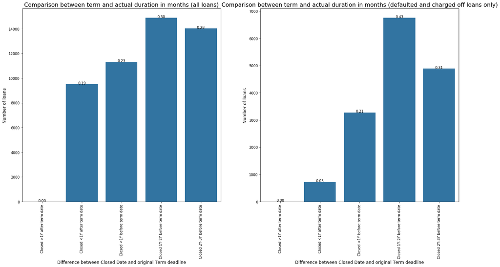

```python
print('Term vs Duration vs Loan Status:\n')
print('I have focused on 3Y loans and created a new variable that takes the \ndifference between Term and Duration in months.')
print('19% of the overall population of loans is closed after the term final date \nwhereas this is true for 5% of the defaulted/charged off loans. This is a \nsign that loans that are meant to default get identified generally earlier \nthan the final date, which is a good thing for Prosper.')
print('31% of the 3Y loans meant to default or be charged off are closed in the \nfirst year. This shows that for almost a third of these loans, signs of \nfinancial distress could be seen quite soon.')

df_loans_3 = df_loans[df_loans['Term']==36]
total_3 = df_loans_3[df_loans_3['TimeDiff_Cat'].notnull()]['ListingNumber'].count()
order_time_3 = ["Closed >1Y after term date", 'Closed <1Y after term date', 'Closed <1Y before term date', 'Closed 1Y-2Y before term date', "Closed 2Y-3Y before term date"]

fig = plt.figure(figsize = (22,10))
plt.subplot(1, 2, 1)
time_3 = sb.countplot(data = df_loans_3, x = 'TimeDiff_Cat', color = base, order = order_time_3)
plt.xticks(rotation=90)

for p in time_3.patches:
    height = p.get_height()
    time_3.text(p.get_x()+p.get_width()/2.,
            height + 3,
            '{:0.2f}'.format(height/total_3),
            ha="center")
plt.title('Comparison between term and actual duration in months (all loans)', size = 16)
plt.xlabel('Difference between Closed Date and original Term deadline', size = 12)
plt.ylabel('Number of loans', size = 12);

plt.subplot(1, 2, 2)
default_off_cat = df_loans[df_loans['LoanStatus'].isin(['Chargedoff', 'Defaulted'])]
total_default_off = default_off_cat[default_off_cat['TimeDiff_Cat'].notnull()]['ListingNumber'].count()
default_off_3 = default_off_cat[default_off_cat['Term']==36]
total_default_off_3 = default_off_3[default_off_3['TimeDiff_Cat'].notnull()]['ListingNumber'].count()
order_time_3 = ["Closed >1Y after term date", 'Closed <1Y after term date', 'Closed <1Y before term date', 'Closed 1Y-2Y before term date', "Closed 2Y-3Y before term date"]

time_off_3 = sb.countplot(data = default_off_3, x = 'TimeDiff_Cat', color = base, order = order_time_3)
plt.xticks(rotation=90)

for p in time_off_3.patches:
    height = p.get_height()
    time_off_3.text(p.get_x()+p.get_width()/2.,
            height + 3,
            '{:0.2f}'.format(height/total_default_off_3),
            ha="center")
plt.title('Comparison between term and actual duration in months (defaulted and charged off loans only)', size = 16)
plt.xlabel('Difference between Closed Date and original Term deadline', size = 12)
plt.ylabel('Number of loans', size = 12);
```

```
Credit Rating vs Homeowner Status vs Loan Status:
```

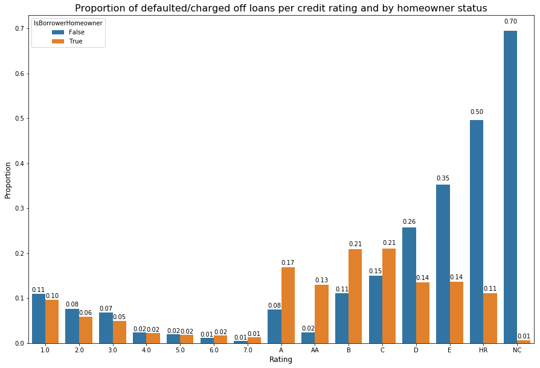

```python
print('Credit Rating vs Homeowner Status vs Loan Status:\n')

df_loans['Rating'] = df_loans['Rating'].astype(str)
multi = pd.DataFrame(default_off.groupby(['IsBorrowerHomeowner', 'Rating'])['ListingNumber'].count()).reset_index()
multi['Rating'] = multi['Rating'].astype(str)
multi_aggr = pd.DataFrame(df_loans.groupby('Rating')['ListingNumber'].count()).reset_index()
multi_visual = multi.merge(multi_aggr, on = 'Rating', how = 'left')
multi_visual['Proportion'] = multi_visual['ListingNumber_x']/multi_visual['ListingNumber_y']

fig = plt.figure(figsize = (15,10))
score_home_final = sb.barplot(data = multi_visual, x = 'Rating', y = 'Proportion', hue = 'IsBorrowerHomeowner')

for rect in score_home_final.patches:
        height = rect.get_height()
        score_home_final.text(rect.get_x() + rect.get_width()/2., 1.02*height,
                '{:0.2f}'.format(height),
                ha='center', va='bottom')
plt.title('Proportion of defaulted/charged off loans per credit rating and by homeowner status', size = 16)
plt.xlabel('Rating', size = 12)
plt.ylabel('Proportion', size = 12);
```

**Comments to earlier plot and conclusion**:

If we look at the first proportion (11%), this shows that 11% of the borrowers with rating equal to 1 are non-homeowners and defaulted or got loans charged off.

Around 50% of the high risk borrowers are non-homeowners that defaulted or got their loans charged off. In total, 61% of the HR borrowers, either homeowners or not, are in this interest group.

As a general trend, we can note that lower rating means a higher proportion of defaulted or charged off loans (21% of the loans with rating equal to 1 and 40% of the loans with rating equal to D defaulted or got charged off).

Also, generally speaking non-homeowners defaulted more than others as we can see their predominance apart from the very high ratings where there is a much higher percentage of homeowners.

In summary, it seems that owning a home and credit rating are good indicators of likelihood of default.